# A Quick R Markdown Tutorial

Yan Zhang

2019/1/21

Introduction

- What is Markdown and R markdown?
- How can I use R markdown?
- What’s the relationship between R and R Studio ?

Preparation

- Step 1, Of course, you need to install R and R Studio first
- Step 2, Copy and paste the code below to download the rmarkdown package in R Studio console (one time)
- Step 3, Creating a new R Markdown file
- Step 4, output options

R Markdown Screenshot

Useful code

Generating a report

References and hyperlinks

# Introduction:

### What is Markdown and R markdown?

> Markdown (John Gruber, https://daringfireball.net/projects/markdown) is a different way to write documents that include computer code. … R markdown is a particular kind of markdown document. — Paul Johnson (“R Markdown Basics”)

### How can I use R markdown?

### R Studio :

#### Pro:

> - Free
> - Inline code
> - Supports R, Python, SQL, C++, etc
> - Standalone enviroment (sort of)

### Anaconda :

#### Pro:

> - Free
> - Inline code
> - Mainly for Python but also supports R
> - Needs a web browser

##### R Studio is the prefered one, because I personally can’t study when my web browser is remaining open

### What’s the relationship between R and R Studio ?

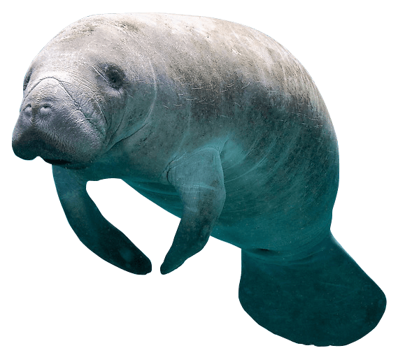

+

[figure not shown]

=

[figure not shown]

##### R Studio is a mask software of R, which means R is a necessary software for R Studio

# Preparation:

### Step 1, Of course, you need to install R and R Studio first:

> R (free and comes with ABSOLUTELY NO WARRANTY): https://cran.r-project.org/mirrors.html

> R Studio (free version is good enough for now): https://www.rstudio.com/products/rstudio/download/

### Step 2, Copy and paste the code below to download the *rmarkdown* package in R Studio console (one time):

```
install.packages("rmarkdown")
```

##### Or just simply do step 3, where R Studio will automatically download it for you but you still can use this code above in your console to show off a bit

### Step 3, creating a new R Markdown file:

[figure not shown]

### Step 4, output options:

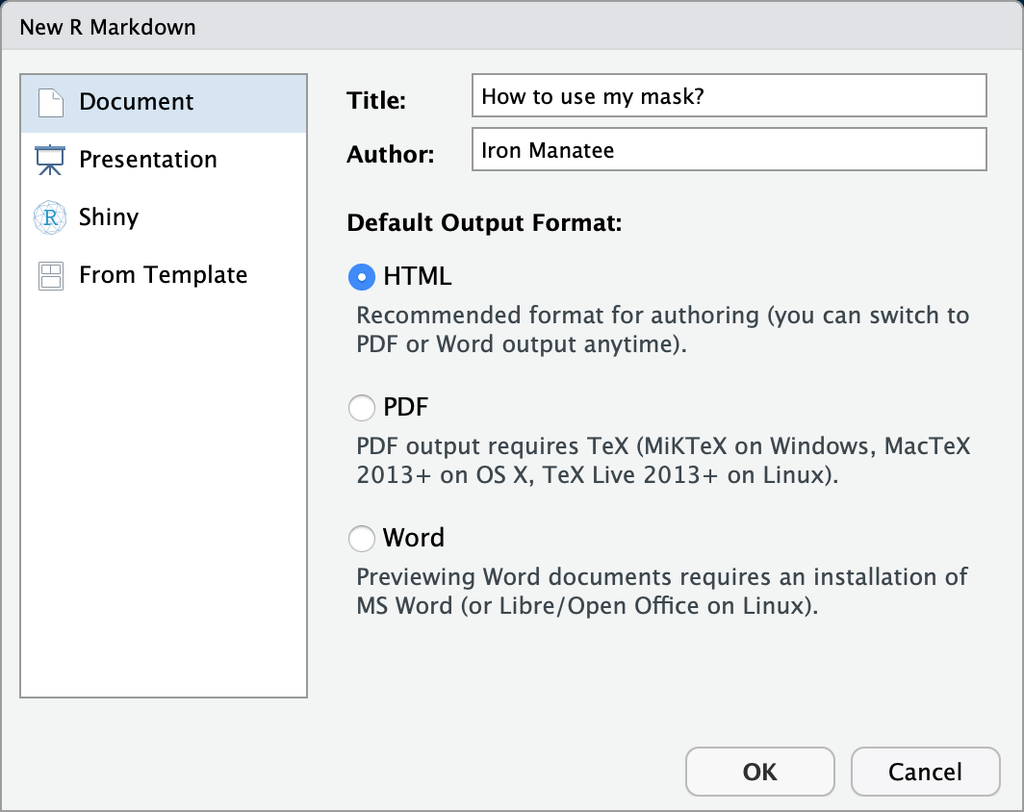

> PDF and Word output require extension software support. For instance, PDF output requaires you to have $\LaTeX$ and Word output requires Microsoft Word

# R Markdown Screenshot:

[figure not shown]

# Useful code:

##### Header:

```
# Header 1
## Header 2
### Header 3
#### Header 4
##### Header 5
###### Header 6
```

# Header 1

## Header 2

### Header 3

#### Header 4

##### Header 5

###### Header 6

##### **bold** and *italics*:

```
This is *Rmarkdown*!

This is _Rmarkdown_!

This is **Rmarkdown**!

This is **_R_ markdown**!

This is *R~~markdown~~*!
```

This is *Rmarkdown*!

This is *Rmarkdown*!

This is **Rmarkdown**!

This is *R* markdown!

This is *Rmarkdown*!

##### List:

```
* unordered list
* item 2
    + sub-item 1
    + sub-item 2
1. ordered list
2. item 2
    + sub-item 1
    + sub-item 2
```

- unordered list
- item 2
  - sub-item 1
  - sub-item 2
1. ordered list
2. item 2
   - sub-item 1
   - sub-item 2

##### $\LaTeX$:

```
$$
A = \pi*r^2
$$
```

$$A = \pi*r^2$$

##### Inline $\LaTeX$:

```
$\LaTeX$ is too easy for me!
```

$\LaTeX$ is too easy for me!

##### R code:

```r
t <- "This class is my favourite course!!!"
print(t)
```

```
## [1] "This class is my favourite course!!!"
```

# Generating a report:

[figure not shown]

##### Of course, you can always change your ouput format in this step

# References and hyperlinks:

```
1. [R Markdown Cheat Sheet](https://www.rstudio.com/wp-content/uploads/2015/02/rmarkdown-cheatsheet.pdf)
2. [R Markdown Reference Guide](https://www.rstudio.com/wp-content/uploads/2015/03/rmarkdown-reference.pdf)
3. [R Studio ![](http://dms.umontreal.ca/wiki/images/thumb/e/e9/RStudio-Ball.png/300px-RStudio-Ball.png){width=25px}: R Markdown Quick Tour](https://rmarkdown.rstudio.com/authoring_quick_tour.html)
4. [R Markdown: The Definitive Guide, by _Yihui Xie, J. J. Allaire, Garrett Grolemund_](https://bookdown.org/yihui/rmarkdown/)
5. [R Markdown Basics, by _Paul Johnson _](https://cran.r-project.org/web/packages/stationery/vignettes/Rmarkdown.pdf)
6. [Homepage of the author with numerous important R packages like _knitr_, Yihui Xie](https://yihui.name)
```

1. [R Markdown Cheat Sheet](https://www.rstudio.com/wp-content/uploads/2015/02/rmarkdown-cheatsheet.pdf)
2. [R Markdown Reference Guide](https://www.rstudio.com/wp-content/uploads/2015/03/rmarkdown-reference.pdf)
3. [R Studio : R Markdown Quick Tour](https://rmarkdown.rstudio.com/authoring_quick_tour.html)
4. [R Markdown: The Definitive Guide, by *Yihui Xie, J. J. Allaire, Garrett Grolemund*](https://bookdown.org/yihui/rmarkdown/)
5. [R Markdown Basics, by *Paul Johnson*](https://cran.r-project.org/web/packages/stationery/vignettes/Rmarkdown.pdf)
6. [Homepage of the author with numerous important R packages like *knitr*, Yihui Xie](https://yihui.name)